# Getting Started With ggplot2

Ysobel Gallo

2023-12-14

## Practice with ggplot2!!

This sheet gives example of ggplot2 diagrams to serve as example syntax and inspiration! If you’re following along, first load the libraries we’ll need for this demonstration: ggplot2 and palmerpenguins.

```r
library(ggplot2)
library(palmerpenguins)
```

## Scatterplot Graph

First up, we have a scatter plot graph showing the relationship between flipper length and body mass across three penguin species.

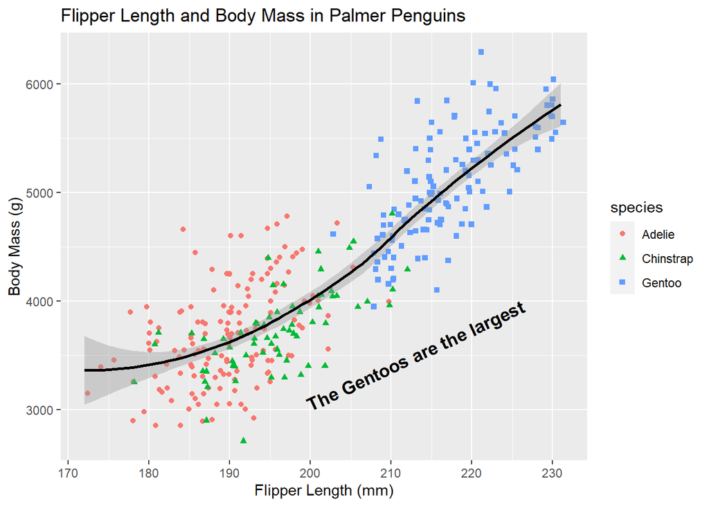

```r
ggplot(data=penguins) +
  geom_jitter(mapping=aes(x=flipper_length_mm,y=body_mass_g,color=species,shape=species))+
  geom_smooth(mapping=aes(x=flipper_length_mm,y=body_mass_g),
              color="black")+
  annotate("text", x=213, y=3500, label="The Gentoos are the largest",
           color="black",fontface="bold",size=4.5,angle=25)+
  labs(title="Flipper Length and Body Mass in Palmer Penguins",
       x="Flipper Length (mm)",
       y="Body Mass (g)")
```

Wow. That was a lot of code. Remember you can always add an `echo = FALSE` parameter to the code chunk to hide the R code that generated the plot. In the future, I’ll only show the code when I’ve done something particularly grand, so you can see what it is.

Oh, speaking of grand, you may have noticed the function geom_jitter. Although most scatterplots are built with geom_point, I used geom_jitter instead to help keep the data points from overlapping, and to allow for an easier read in a large data set.